# Assignment 4

Author

Carmen Hoyt

# Load Packages

```r
library(sensitivity)
library(tidyverse)
library(gridExtra)
library(purrr)
library(ggpubr)
library(here)
```

# Generate Parameters

1. Windspeeds (v):
- normally distributed
- mean of 300 cm/s
- standard deviation of 50 cm/s
2. Vegetation height (height):
- between 3.5 and 5.5 m (but any value in that range is equally likely)
3. k_d and k_0 parameters:
- normally distributed
- standard deviation of 1% of their default values

# Sobol Analysis

1. Use the Sobol approach to generate parameter values for the 4 parameters

```r
source(here("Catm.R"))

# generate two examples of random number from parameter distributions

# number of samples
np <- 1000

# example 1
k_o <- rnorm(mean = 0.1, sd = 0.1 * 0.01, n = np)
k_d <- rnorm(mean = 0.7, sd = 0.7 * 0.01, n = np)
# in meters/s
v <- rnorm(mean = 3, sd = 0.5, n = np)
height <- runif(min = 3.5, max = 5.5, n = np)

X1 <- cbind.data.frame(k_o, k_d, v, height = height)

#example 2
# repeat sampling
k_o <- rnorm(mean = 0.1, sd = 0.1 * 0.01, n = np)
k_d <- rnorm(mean = 0.7, sd = 0.7 * 0.01, n = np)
# in meters/s
v <- rnorm(mean = 3, sd = 0.5, n = np)
height <- runif(min = 3.5, max = 5.5, n = np)

X2 <- cbind.data.frame(k_o, k_d, v, height = height)

# Use a Sobol approach implemented by jansen
sens_Catm_Sobol <- sobolSalt(model = NULL, X1, X2, nboot = 100)

#str(sens_Catm_Sobol)

# Take a look at the Sobol generated sensitivity object
# your parameters sets for sensitivity analysis are in X
#sens_Catm_Sobol$X
```

2. Run the atmospheric conductance model for these parameters

```r
# Turn results into df
parms <- as.data.frame(sens_Catm_Sobol$X)

# Name the parameters
colnames(parms) <- colnames(X1)

# Run model for all parameter sets
res <- pmap_dbl(parms, Catm)

# Check
length(res) == nrow(parms)
```

```
[1] TRUE
```

```r
# Supply model outputs
sens_Catm_Sobol <- sensitivity::tell(sens_Catm_Sobol, res, res.names = "ga")
```

3. Plot conductance estimates in a way that accounts for parameter uncertainty

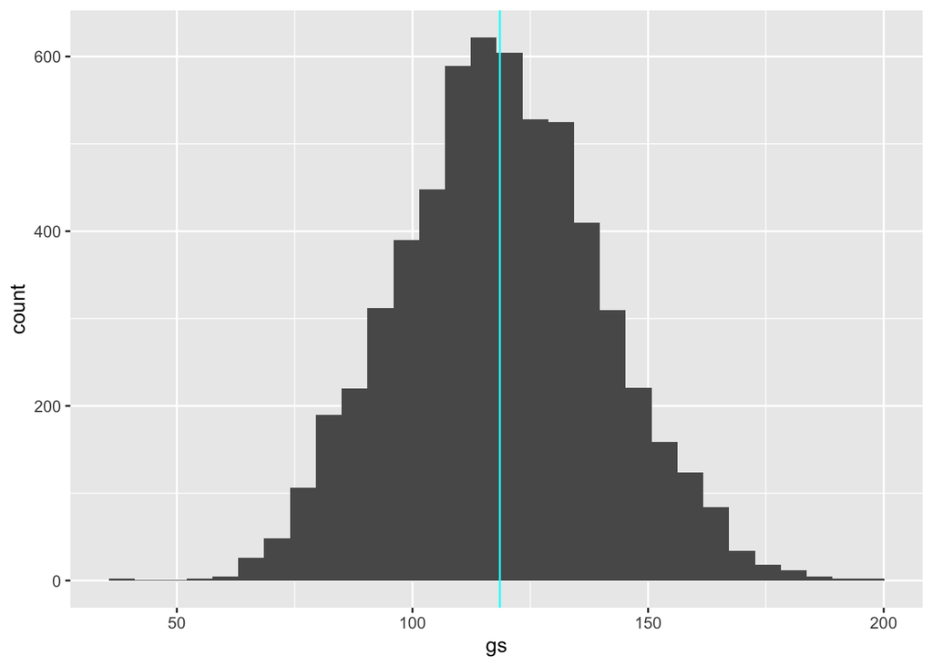

```r
# Graph two most sensitive parameters
both <- cbind.data.frame(parms, gs = sens_Catm_Sobol$y) #gs is atmostpheric conductance (results)

# look at overall gs sensitvity to uncertainty
ggplot(both, aes(x = gs)) +
  geom_histogram() +
  geom_vline(xintercept = mean(both$gs), col = "cyan")
```

4. Plot conductance estimates against windspeed use the parameter that is 2nd in terms of total effect on response

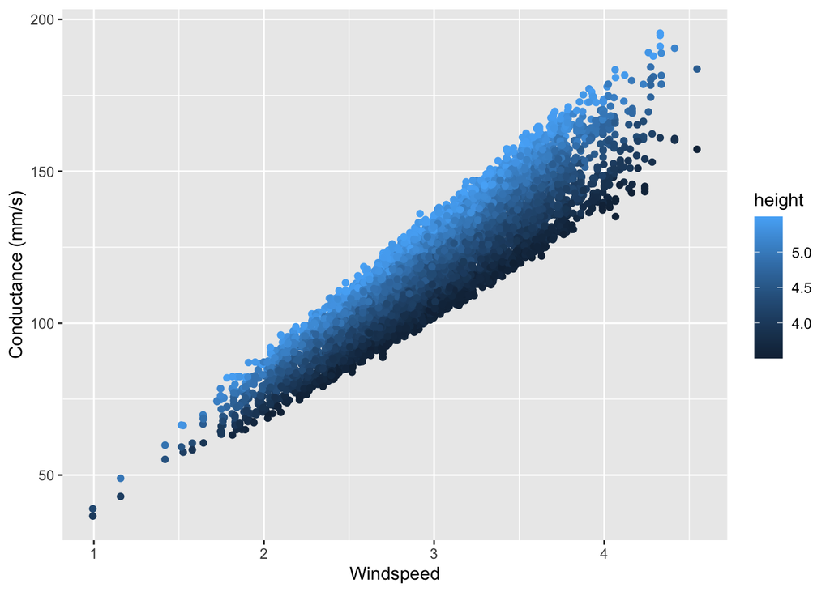

```r
# look at response of conductance to the two interesting variables
ggplot(both, aes(v, gs, col = height)) +
  geom_point() +
  # conductance as a function of windspeed (height isnt making much diff i.e. color)
  labs(y = "Conductance (mm/s)", x = "Windspeed")
```

5. Estimate the Sobel Indices for your output

```r
# Quanitify Sobol indices
# main effect:  partitions variance (main effect without co-variance) - sums approximately to one
sens_Catm_Sobol$S
```

```
      original          bias std. error   min. c.i.  max. c.i.
X1 -0.06282233 -0.0064420603 0.03186594 -0.11620358 0.01112038
X2 -0.06429074 -0.0060022710 0.03134513 -0.11887902 0.00827018
X3  0.80623316  0.0001429346 0.01077193  0.78521594 0.82972986
X4  0.14227252 -0.0046829073 0.02918283  0.08723006 0.20182027
```

```r
# useful to add names
row.names(sens_Catm_Sobol$S) <- colnames(parms)
sens_Catm_Sobol$S # S is the main effect
```

[output not shown]

```r
# total effect - accounts for parameter interactions
row.names(sens_Catm_Sobol$T) <- colnames(parms)
sens_Catm_Sobol$T # T is the total effect
```

[output not shown]

```r
# Both the main effect and total effect can tell us something about how the parameter influences results

print(sens_Catm_Sobol)
```

[output not shown]

6. Comment on what this tells you about how atmospheric conductance and its sensitivity to variation in windspeed differs in this setting as compared to the setting that we examined in class where windspeed was lower and less variable and vegetation was taller.

Atmospheric conductance is *more* sensitive to windspeed in this setting (with higher, more variable windespeed and shorter vegetation) vs. the setting we examined in class (with lower, less variable windspeed and taller vegetation). We know this by comparing the Sobol indices, where the indices for v and height are higher in this setting than the class setting, where k_d was the most sensitive (highest indice) parameter. This shed light on the role of windspeed and vegetation on atmospheric conductance, specifically concerning water vapor flux, in different environments.